## Linear mixed-effect models (LMMs)

**Recall:** Blocking helps control variability by making treatment groups more alike. Experimental units are divided into subsets (called blocks) so that units within the same block are more similar than units from different subsets or blocks. Blocking is a technique for dealing with nuisance factors. A nuisance factor is a factor that has some effect on the response, but is of no interest (e.g., age class).

**Fixed effects** are terms (parameters) in a statistical model which are fixed, or non-random, quantities (e.g., *treatment* group’s mean response). For the same *treatment*, we expect this quantity to be the same from experiment to experiment.

**Random effects** are terms (parameters) in a statistical model which are considered as random quantities or variables (e.g., block id). Specifically, terms whose levels are a representative sample from a population, and where the variance of the population is of interest should be allocated as random. Setting a block as a random effect allows us to infer variation between blocks as well as the variation between experimental units within blocks.

**Key idea:** Partition known sources of variation which are unimportant to key scientific question(s) to improve precision of comparisons between treatment means.

### A Randomised Controlled Block Design (RCBD)

| Run | Surgery | Rat | logAUC8 |
| --- | --- | --- | --- |
| 1 | C | 1 | 9.24 |
| 1 | P | 2 | 8.81 |
| 1 | S | 3 | 10.75 |
| 2 | C | 4 | 3.89 |
| 2 | P | 5 | 8.62 |
| 2 | S | 6 | 10.24 |
| 3 | C | 7 | 8.42 |
| 3 | P | 8 | 9.93 |
| 3 | S | 9 | 11.68 |
| 4 | C | 10 | 8.77 |
| 4 | P | 11 | 10.86 |
| 4 | S | 12 | 13.05 |

#### `Run` as a fixed effect

```r
lm <- lm(logAUC8 ~ Run + Surgery, data = rcbd)
summary(lm)
```

```
##
## Call:
## lm(formula = logAUC8 ~ Run + Surgery, data = rcbd)
##
## Residuals:
##     Min      1Q  Median      3Q     Max
## -1.7517 -0.3683 -0.0900  0.4508  1.5817
##
## Coefficients:
##             Estimate Std. Error t value Pr(>|t|)
## (Intercept)   7.6583     0.8506   9.004 0.000105 ***
## Run2         -2.0167     0.9822  -2.053 0.085854 .
## Run3          0.4100     0.9822   0.417 0.690882
## Run4          1.2933     0.9822   1.317 0.235963
## SurgeryP      1.9750     0.8506   2.322 0.059293 .
## SurgeryS      3.8500     0.8506   4.526 0.003991 **
## ---
## Signif. codes:  0 '***' 0.001 '**' 0.01 '*' 0.05 '.' 0.1 ' ' 1
##
## Residual standard error: 1.203 on 6 degrees of freedom
## Multiple R-squared:  0.8449, Adjusted R-squared:  0.7157
## F-statistic: 6.538 on 5 and 6 DF,  p-value: 0.02034
```

#### `Run` as a random effect

```r
lmer_mod <- lmerTest::lmer(logAUC8 ~ Surgery + (1|Run), data = rcbd)
summary(lmer_mod)
```

```
## Linear mixed model fit by REML. t-tests use Satterthwaite's method [
## lmerModLmerTest]
## Formula: logAUC8 ~ Surgery + (1 | Run)
##    Data: rcbd
##
## REML criterion at convergence: 37.2
##
## Scaled residuals:
##     Min      1Q  Median      3Q     Max
## -1.8525 -0.2273  0.1772  0.4036  1.3309
##
## Random effects:
##  Groups   Name        Variance Std.Dev.
##  Run      (Intercept) 1.479    1.216
##  Residual             1.447    1.203
## Number of obs: 12, groups:  Run, 4
##
## Fixed effects:
##             Estimate Std. Error     df t value Pr(>|t|)
## (Intercept)   7.5800     0.8552 5.9567   8.863 0.000119 ***
## SurgeryP      1.9750     0.8506 6.0000   2.322 0.059293 .
## SurgeryS      3.8500     0.8506 6.0000   4.526 0.003991 **
## ---
## Signif. codes:  0 '***' 0.001 '**' 0.01 '*' 0.05 '.' 0.1 ' ' 1
##
## Correlation of Fixed Effects:
##          (Intr) SrgryP
## SurgeryP -0.497
## SurgeryS -0.497  0.500
```

##### Inference about the *Random effects*

We have two variance components

- Between Groups (Runs) $\hat{\sigma^2}_{\text{Run}}$ = 1.479
- Within Runs (between observations) $\hat{\sigma_2}$ = 1.447

Note that `aov()` presents the same information, but in a different way:

```r
summary(aov(logAUC8 ~ Surgery + Error(Run), data = rcbd))
```

```
##
## Error: Run
##           Df Sum Sq Mean Sq F value Pr(>F)
## Residuals  3  17.65   5.883
##
## Error: Within
##           Df Sum Sq Mean Sq F value Pr(>F)
## Surgery    2 29.652  14.826   10.25 0.0116 *
## Residuals  6  8.682   1.447
## ---
## Signif. codes:  0 '***' 0.001 '**' 0.01 '*' 0.05 '.' 0.1 ' ' 1
```

- Within Runs (Residuals) $\hat{\sigma}_2$ = 1.447 (*same as `lmer`*)
- Between Run variance = $\hat{\sigma}^2$ + $3\:\hat{\sigma}^2_{\text{Run}}$ so $\hat{\sigma}^2_{\text{Run}} = \frac{5.883 - \hat{\sigma}^2 }{3} = \frac{5.883 - 1.447}{3} = 1.479$

### A Split-plot design

| Disease | Organ | Animal | Sample | logAUC |
| --- | --- | --- | --- | --- |
| Healthy | innerLV | 1 | 1 | 9.40 |
| Healthy | outerLV | 1 | 2 | 8.83 |
| Healthy | innerLV | 2 | 1 | 10.33 |
| Healthy | outerLV | 2 | 2 | 10.49 |
| Healthy | innerLV | 3 | 1 | 9.74 |
| Healthy | outerLV | 3 | 2 | 10.98 |
| Diabetic | innerLV | 4 | 1 | 7.92 |
| Diabetic | outerLV | 4 | 2 | 9.37 |
| Diabetic | innerLV | 5 | 1 | 8.69 |
| Diabetic | outerLV | 5 | 2 | 11.31 |
| Diabetic | innerLV | 6 | 1 | 7.01 |
| Diabetic | outerLV | 6 | 2 | 9.29 |

#### `Animal` as a random effect

**Using `aov()`**

```r
sp_aov <- aov(logAUC ~ Disease*Organ + Error(Animal), data = split_plot)
summary(sp_aov)
```

```
##
## Error: Animal
##           Df Sum Sq Mean Sq F value Pr(>F)
## Disease    1  3.183   3.183   2.187  0.213
## Residuals  4  5.822   1.456
##
## Error: Within
##               Df Sum Sq Mean Sq F value Pr(>F)
## Organ          1  4.296   4.296  14.423 0.0191 *
## Disease:Organ  1  2.539   2.539   8.525 0.0433 *
## Residuals      4  1.191   0.298
## ---
## Signif. codes:  0 '***' 0.001 '**' 0.01 '*' 0.05 '.' 0.1 ' ' 1
```

**Using `lmer()` (from `lmeTest` and `lmer4`)**

```r
sp_lmer <- lmerTest::lmer(logAUC ~ Disease*Organ + (1|Animal),
                          data = split_plot) ## MUST SPECIFY WHICH PACKAGE
anova(sp_lmer,type = 2)
```

```
## Type II Analysis of Variance Table with Satterthwaite's method
##               Sum Sq Mean Sq NumDF DenDF F value  Pr(>F)
## Disease       0.6513  0.6513     1     4  2.1866 0.21329
## Organ         4.2960  4.2960     1     4 14.4227 0.01914 *
## Disease:Organ 2.5392  2.5392     1     4  8.5246 0.04326 *
## ---
## Signif. codes:  0 '***' 0.001 '**' 0.01 '*' 0.05 '.' 0.1 ' ' 1
```

```r
sp_lmer4 <- lme4::lmer(logAUC ~ Disease*Organ + (1|Animal), data = split_plot) ## MUST SPECIFY WHICH PACKAGE
predmeans <- predictmeans::predictmeans(model = sp_lmer4 ,modelterm = "Disease:Organ")
predmeans$mean_table
```

```
##    Disease   Organ Predicted means Standard error Df LL of 95% CI UL of 95% CI
## 1 Diabetic innerLV        7.873333      0.5405835  4     6.372433     9.374234
## 2 Diabetic outerLV        9.990000      0.5405835  4     8.489099    11.490901
## 3  Healthy innerLV        9.823333      0.5405835  4     8.322433    11.324234
## 4  Healthy outerLV       10.100000      0.5405835  4     8.599099    11.600901
```

### A repeated measures design (time points as factors)

```r
liver <- read_csv("https://raw.githubusercontent.com/STATS-UOA/databunker/master/data/repeated_measures_liver.csv")
## change time to factor
liver$Time <- as.factor(liver$Time) ## this is important
liver$Treatment <- as.factor(liver$Treatment)
liver
```

```
## # A tibble: 210 × 4
##    Animal   Treatment Time  Glucose
##    <chr>    <fct>     <fct>   <dbl>
##  1 Control1 Control   0        1.60
##  2 Control1 Control   5        1.28
##  3 Control1 Control   10       1.60
##  4 Control1 Control   15       1.58
##  5 Control1 Control   20       1.28
##  6 Control1 Control   25       1.44
##  7 Control1 Control   30       1.18
##  8 Control2 Control   0        0.84
##  9 Control2 Control   5        0.64
## 10 Control2 Control   10       0.7
## # … with 200 more rows
```

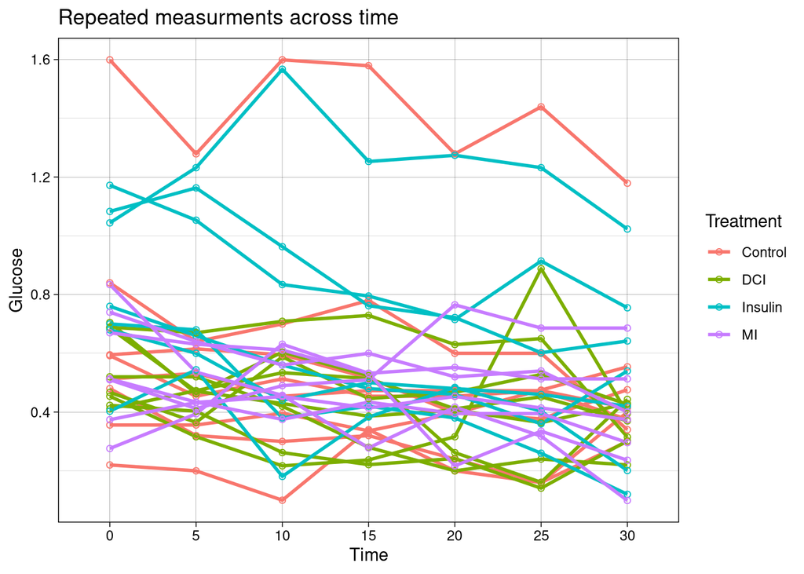

[output not shown]

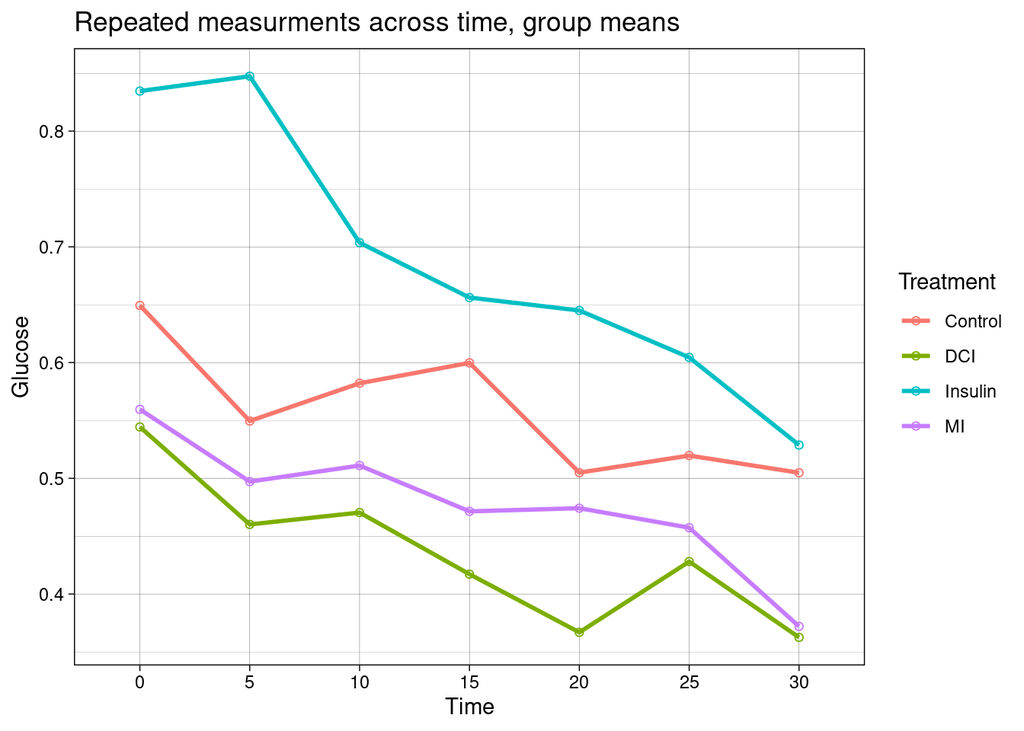

### `Animal` as a random effect in linear regression

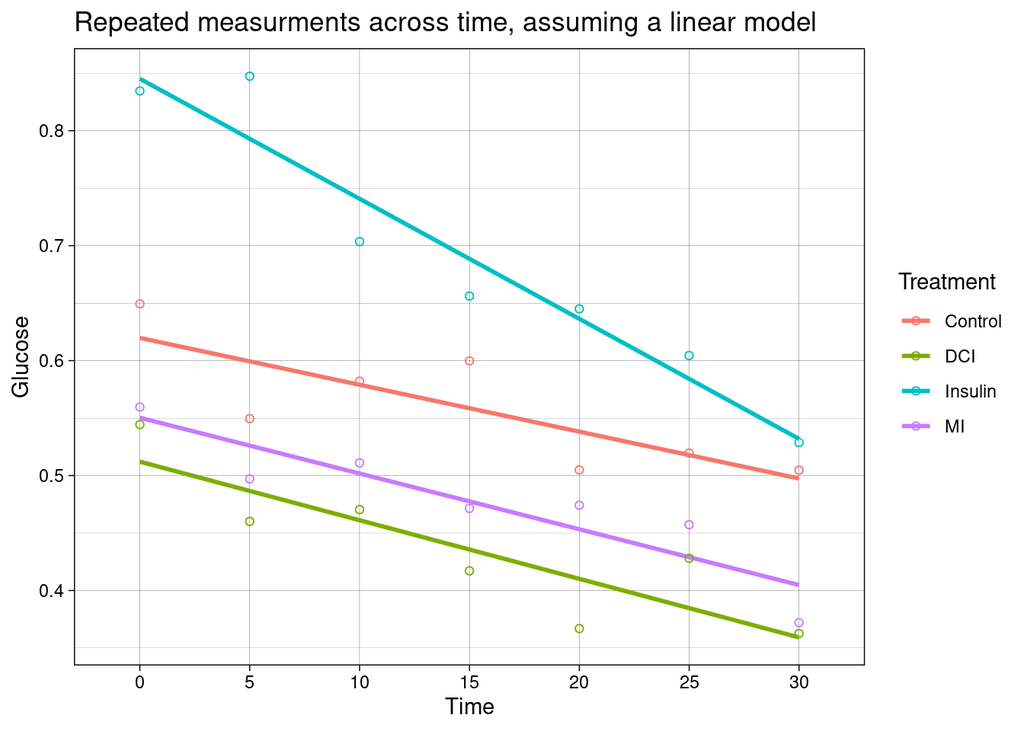

**Using `aov()`**

```r
re_aov <- aov(Glucose ~ Treatment*Time + Error(Animal),data = liver)
summary(re_aov)
```

```
##
## Error: Animal
##           Df Sum Sq Mean Sq F value Pr(>F)
## Treatment  3   1.90  0.6335   1.407  0.263
## Residuals 26  11.71  0.4503
##
## Error: Within
##                 Df Sum Sq Mean Sq F value       Pr(>F)
## Time             6 0.7973 0.13289   8.732 0.0000000334 ***
## Treatment:Time  18 0.2539 0.01411   0.927        0.547
## Residuals      156 2.3741 0.01522
## ---
## Signif. codes:  0 '***' 0.001 '**' 0.01 '*' 0.05 '.' 0.1 ' ' 1
```

**Using `lmer()` (from `lmerTest` and `lme4`)**

```r
re_lmer <- lmerTest::lmer(Glucose ~ Treatment*Time + (1|Animal), data = liver) ## MUST SPECIFY WHICH PACKAGE
anova(re_lmer,type = 2)
```

```
## Type II Analysis of Variance Table with Satterthwaite's method
##                 Sum Sq  Mean Sq NumDF DenDF F value        Pr(>F)
## Treatment      0.06423 0.021409     3    26  1.4068        0.2632
## Time           0.79731 0.132885     6   156  8.7318 0.00000003345 ***
## Treatment:Time 0.25390 0.014105    18   156  0.9269        0.5474
## ---
## Signif. codes:  0 '***' 0.001 '**' 0.01 '*' 0.05 '.' 0.1 ' ' 1
```

```r
re_lmer4 <- lme4::lmer(Glucose ~ Treatment*Time + (1|Animal),data = liver) ## MUST SPECIFY WHICH PACKAGE
predmeans <- predictmeans::predictmeans(model = re_lmer4 ,modelterm = "Treatment:Time")
predmeans$mean_table
```

```
##    Treatment Time Predicted means Standard error  Df LL of 95% CI UL of 95% CI
## 1    Control    0       0.6493750     0.09834458 156    0.4551162    0.8436338
## 2    Control    5       0.5495000     0.09834458 156    0.3552412    0.7437588
## 3    Control   10       0.5821250     0.09834458 156    0.3878662    0.7763838
## 4    Control   15       0.5997500     0.09834458 156    0.4054912    0.7940088
## 5    Control   20       0.5048750     0.09834458 156    0.3106162    0.6991338
## 6    Control   25       0.5196250     0.09834458 156    0.3253662    0.7138838
## 7    Control   30       0.5047500     0.09834458 156    0.3104912    0.6990088
## 8        DCI    0       0.5443750     0.09834458 156    0.3501162    0.7386338
## 9        DCI    5       0.4601250     0.09834458 156    0.2658662    0.6543838
## 10       DCI   10       0.4703750     0.09834458 156    0.2761162    0.6646338
## 11       DCI   15       0.4171250     0.09834458 156    0.2228662    0.6113838
## 12       DCI   20       0.3668750     0.09834458 156    0.1726162    0.5611338
## 13       DCI   25       0.4280000     0.09834458 156    0.2337412    0.6222588
## 14       DCI   30       0.3625000     0.09834458 156    0.1682412    0.5567588
## 15   Insulin    0       0.8345714     0.10513478 156    0.6269000    1.0422428
## 16   Insulin    5       0.8474286     0.10513478 156    0.6397572    1.0551000
## 17   Insulin   10       0.7035714     0.10513478 156    0.4959000    0.9112428
## 18   Insulin   15       0.6561429     0.10513478 156    0.4484714    0.8638143
## 19   Insulin   20       0.6450000     0.10513478 156    0.4373286    0.8526714
## 20   Insulin   25       0.6044286     0.10513478 156    0.3967572    0.8121000
## 21   Insulin   30       0.5287143     0.10513478 156    0.3210429    0.7363857
## 22        MI    0       0.5595714     0.10513478 156    0.3519000    0.7672428
## 23        MI    5       0.4971429     0.10513478 156    0.2894714    0.7048143
## 24        MI   10       0.5110000     0.10513478 156    0.3033286    0.7186714
## 25        MI   15       0.4714286     0.10513478 156    0.2637572    0.6791000
## 26        MI   20       0.4741429     0.10513478 156    0.2664714    0.6818143
## 27        MI   25       0.4572857     0.10513478 156    0.2496143    0.6649571
## 28        MI   30       0.3720000     0.10513478 156    0.1643286    0.5796714
```